# Treatment assignment

Choose randomized, selected, or fixed treatment timing.

The assignment model decides which units receive treatment and when. It can use panel dimensions, observed features, and latent features. Its output is an $N \times T$ binary treatment matrix.

## 1 Choose an assignment family

| Scientific design | Class | Main inputs |
| --- | --- | --- |
| One fixed treated cohort | `SingleCohortAssignment` | treated unit positions, adoption period |
| One randomized cohort | `RandomizedSingleCohortAssignment` | cohort size, adoption period |
| Fixed staggered adoption | `StaggeredAdoption` | unit-to-period map |
| Randomized staggered adoption | `RandomizedStaggeredAdoption` | periods and cohort sizes |
| Binary selection | `BinaryLogitAssignment` | observed and latent logit coefficients |
| Sparse binary selection | `SparseLogitAssignment` | selected covariate indices and coefficients |
| Multiple adoption categories | `GeneralizedPropensityAssignment` | category-specific logits |

Use randomized assignment to study estimator behavior under known overlap. Use feature-dependent assignment to study confounding or conditional identifying assumptions. Use fixed assignment to reproduce a specific schedule.

## 2 Common simulation components

The examples below share the same features, untreated outcomes, and treatment effects. Only assignment changes.

```python
import matplotlib.pyplot as plt
import numpy as np

from pypanelsim import core, primitives

dimensions = core.PanelDimensions(n_units=240, n_periods=48)
features = primitives.GaussianUnitFeatures(
    n_observables=2,
    n_unobservables=1,
)
outcome = primitives.SumOutcomeModel(
    models=(
        primitives.TwoWayFixedEffectsOutcome(noise_scale=0.4),
        primitives.LinearFeatureOutcome(
            level_coefficients=(1.0, -0.5),
            trend_coefficients=(0.0, 0.0),
            source="observables",
        ),
        primitives.LinearFeatureOutcome(
            level_coefficients=(0.8,),
            trend_coefficients=(0.0,),
            source="unobservables",
        ),
    )
)
effect = primitives.LinearRampEffect(slope=0.12)

def make_simulator(name, assignment):
    return core.PanelSimulator(
        name=name,
        dimensions=dimensions,
        feature_model=features,
        assignment=assignment,
        outcome_model=outcome,
        effect_model=effect,
    )
```

## 3 Randomized assignment

One cohort starts treatment in period 30:

```python
randomized = make_simulator(
    "randomized_single_cohort",
    primitives.RandomizedSingleCohortAssignment(
        n_treated=96,
        adoption_period=30,
    ),
).simulate(seed=42)

print(randomized.treated_units.size)
print(randomized.adoption_times[randomized.ever_treated][:5])
```

```
96
[30 30 30 30 30]
```

For staggered adoption, give one size for each adoption period:

```python
staggered = make_simulator(
    "randomized_staggered",
    primitives.RandomizedStaggeredAdoption(
        adoption_periods=(24, 30, 36),
        cohort_sizes=(32, 32, 32),
    ),
).simulate(seed=42)

print(sorted(set(staggered.adoption_times[staggered.ever_treated])))
```

```
[np.int64(24), np.int64(30), np.int64(36)]
```

These classes sample without replacement. Any unit not sampled is never treated.

## 4 Selection with a binary logit

For unit $i$, `BinaryLogitAssignment` uses

$$P(A_i=1 \mid X_i,U_i)
= \operatorname{logit}^{-1}
\left(\alpha + X_i'\beta + U_i'\gamma\right).$$

Here $X_i$ is observable to the estimator and $U_i$ is latent.

```python
selected = make_simulator(
    "selected_single_cohort",
    primitives.BinaryLogitAssignment(
        adoption_period=30,
        intercept=-0.3,
        observable_coefficients=(0.8, -0.4),
        unobservable_coefficients=(0.9,),
    ),
).simulate(seed=42)

print(selected.treated_units.size)
print(selected.unit_covariate_names)
```

```
111
('x1', 'x2')
```

The same latent feature affects untreated outcomes and assignment. The design therefore has unobserved selection by construction.

## 5 Multiple adoption categories

`GeneralizedPropensityAssignment` assigns each unit to never treated or to one of several adoption periods. Its logits compare each treated category with the never-treated reference category.

```python
multi = make_simulator(
    "selected_staggered",
    primitives.GeneralizedPropensityAssignment(
        adoption_periods=(24, 30, 36),
        intercepts=(-0.8, -0.6, -0.9),
        observable_coefficients=(
            (0.8, 0.0),
            (0.0, -0.7),
            (0.4, 0.4),
        ),
        unobservable_coefficients=((0.6,), (0.3,), (-0.4,)),
    ),
).simulate(seed=42)

print(sorted(set(multi.adoption_times[multi.ever_treated])))
```

```
[np.int64(24), np.int64(30), np.int64(36)]
```

The selected category is stored as the unit annotation `assignment_category`.

## 6 Visual comparison

The following panels use the same feature and outcome models. Their treatment patterns differ because assignment changes.

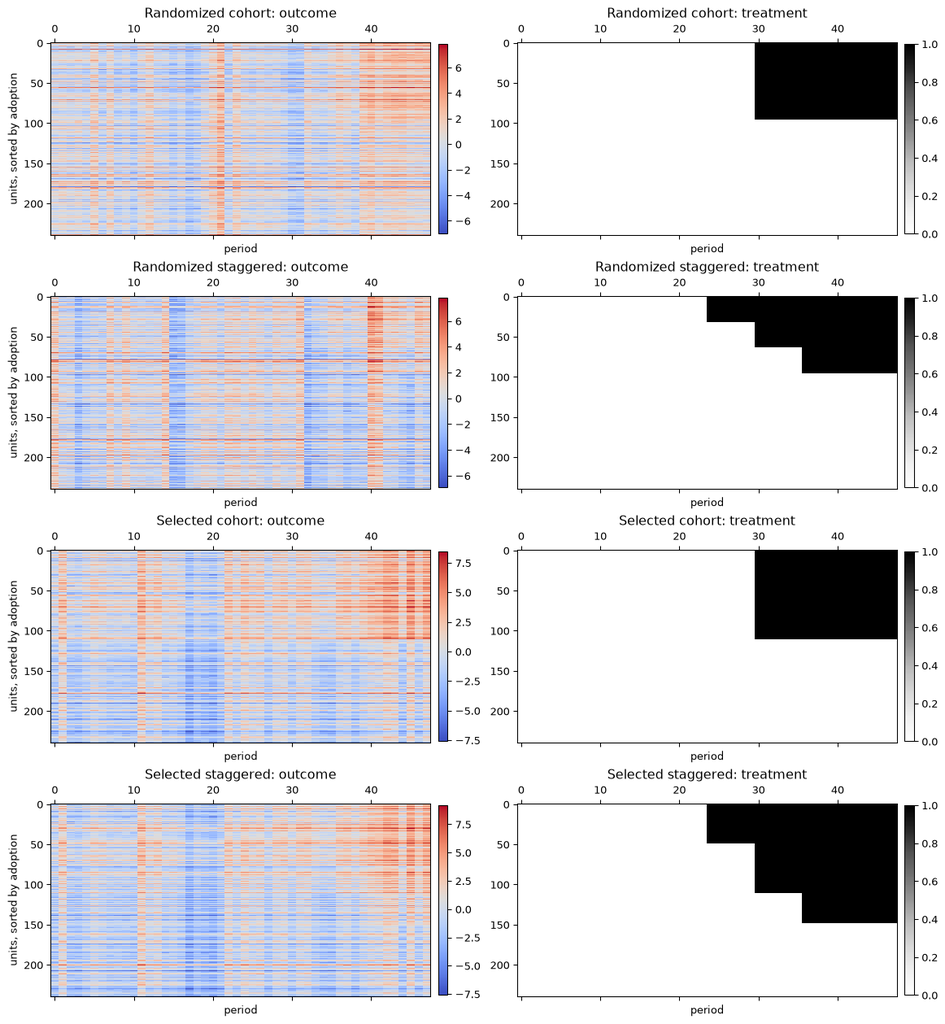

Figure 1: A common outcome model under randomized, selected, and staggered treatment assignment.

```python
assignment_panels = {
    "Randomized cohort": randomized,
    "Randomized staggered": staggered,
    "Selected cohort": selected,
    "Selected staggered": multi,
}

figure, axes = plt.subplots(4, 2, figsize=(12, 13), constrained_layout=True)
for row, (label, draw) in enumerate(assignment_panels.items()):
    order = np.argsort(draw.adoption_times, kind="stable")
    outcome_image = axes[row, 0].matshow(
        draw.outcome[order],
        aspect="auto",
        cmap="coolwarm",
    )
    treatment_image = axes[row, 1].matshow(
        draw.treatment[order],
        aspect="auto",
        cmap="Greys",
        vmin=0.0,
        vmax=1.0,
    )
    axes[row, 0].set_title(f"{label}: outcome")
    axes[row, 1].set_title(f"{label}: treatment")
    axes[row, 0].set_ylabel("units, sorted by adoption")
    figure.colorbar(outcome_image, ax=axes[row, 0], fraction=0.025, pad=0.02)
    figure.colorbar(treatment_image, ax=axes[row, 1], fraction=0.025, pad=0.02)
    for axis in axes[row]:
        axis.set_xlabel("period")
plt.show()
```

## 7 Unit-time effect heterogeneity

An effect callable receives the same observed, latent, and time features as the other components. It returns the potential effect for every cell. The simulator sets the realized effect to zero outside treated cells.

```python
heterogeneous_simulator = core.PanelSimulator(
    name="heterogeneous_effects",
    dimensions=dimensions,
    feature_model=features,
    time_feature_model=primitives.GaussianTimeFeatures(1),
    assignment=primitives.RandomizedSingleCohortAssignment(
        n_treated=80,
        adoption_period=30,
    ),
    outcome_model=outcome,
    effect_model=lambda context: (
        (
            1.0
            + 0.45 * context.observables[:, 0]
            - 0.30 * context.observables[:, 1]
            + 0.80 * context.unobservables[:, 0]
        )[:, None]
        * (1.0 + 0.30 * context.time_features[:, 0])[None, :]
    ),
)
heterogeneous_panel = heterogeneous_simulator.simulate(seed=42)
```

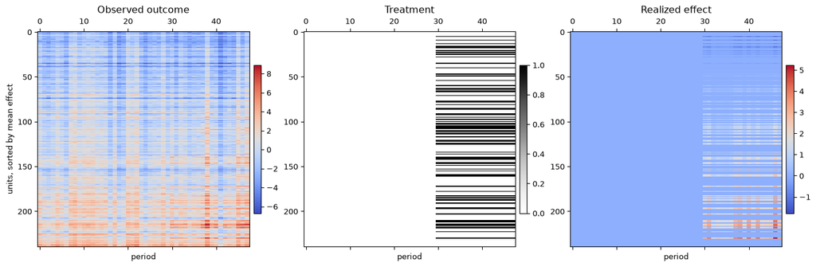

Figure 2: Observed outcomes, treatment, and the realized heterogeneous effect.

```python
order = np.argsort(heterogeneous_panel.effect_surface.mean(axis=1), kind="stable")
figure, axes = plt.subplots(1, 3, figsize=(14, 4.5), constrained_layout=True)
plot_panels = (
    (heterogeneous_panel.outcome, "Observed outcome", "coolwarm", None, None),
    (heterogeneous_panel.treatment, "Treatment", "Greys", 0.0, 1.0),
    (
        heterogeneous_panel.treatment_effect,
        "Realized effect",
        "coolwarm",
        None,
        None,
    ),
)
for axis, (values, title, color_map, lower, upper) in zip(
    axes,
    plot_panels,
    strict=True,
):
    image = axis.matshow(
        values[order],
        aspect="auto",
        cmap=color_map,
        vmin=lower,
        vmax=upper,
    )
    axis.set_title(title)
    axis.set_xlabel("period")
    figure.colorbar(image, ax=axis, fraction=0.035, pad=0.02)
axes[0].set_ylabel("units, sorted by mean effect")
plt.show()
```

## 8 Assignment metadata

Every simulated panel records the assignment class and its draw metadata:

```python
print(selected.metadata["assignment"]["model"])
print(selected.unit_annotations.keys())
```

```
BinaryLogitAssignment
dict_keys(['ever_treated', 'adoption_period'])
```

Metadata records what the assignment step drew. A design name alone does not state an identifying assumption. Report whether assignment is random, depends on observed features, or depends on latent features.

See the building-block API for parameter definitions.